# L04 ggplot III

Data Visualization (STAT 302)

# Overview

The goal of this lab is to continue the process of unlocking the power of `ggplot2` through constructing and experimenting with a few basic plots.

# Datasets

We’ll be using data from the `blue_jays.rda`, `tech_stocks.rda`, `corruption.rda`, and `cdc.txt` datasets which are already in the `/data` subdirectory in our **data_vis_labs** project.

```r
# Load package(s)

# Load datasets

# Read in the cdc dataset
cdc <- read_delim(file = "data/cdc.txt", delim = "|") %>%
  mutate(genhlth = factor(genhlth,
    levels = c("excellent", "very good", "good", "fair", "poor")
  ))
```

# Exercises

Complete the following exercises.

### Exercise 1

Using `blue_jays.rda` dataset, recreate the following graphic as precisely as possible.

*Hints:*

- Transparency is 0.6
- Point size 2
- Shift text horizontally by 0.5
- See pg 44 in *ggplot2*

```r
# Data for labels
label_info <- blue_jays %>%
  filter(BirdID %in% c("702-90567", "1142-05914"))
```

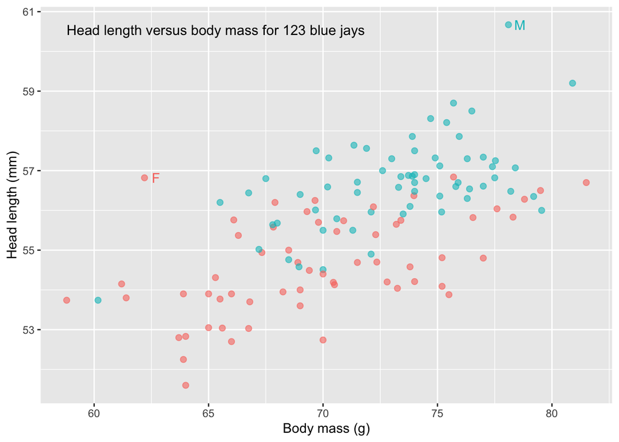

### Exercise 2

Using `tech_stocks` dataset, recreate the following graphics as precisely as possible.

##### Plot 1

*Hints:*

- serif font

```r
# Data for labels
label_info <- tech_stocks %>%
  arrange(desc(date)) %>%
  distinct(company, .keep_all = TRUE)
```

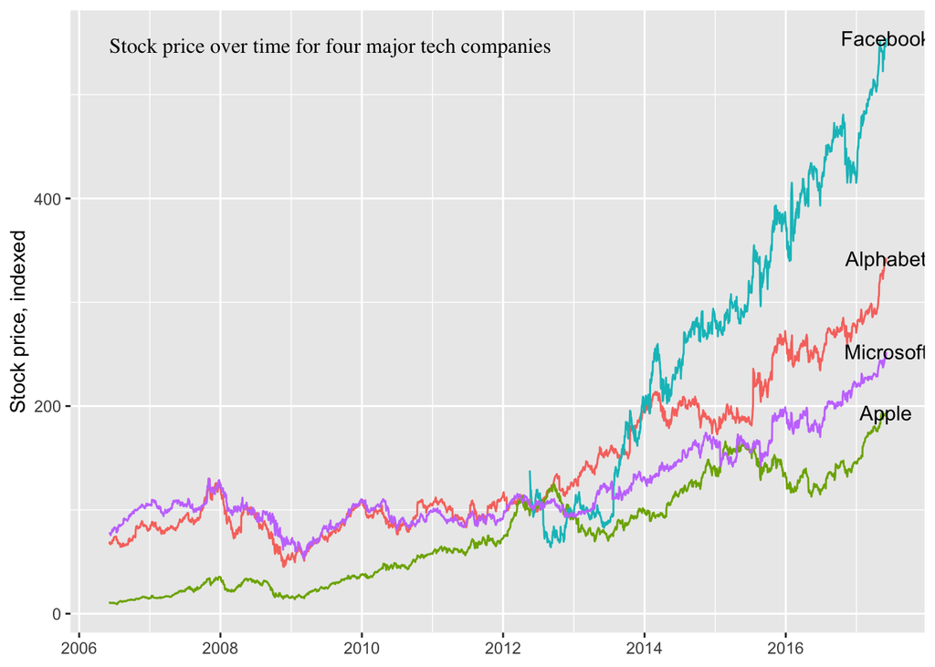

##### Plot 2

*Hints:*

- Package `ggrepel`
- `box.padding` is 0.6
- Minimum segment length is 0
- Horizontal justification is to the right
- seed of 9876

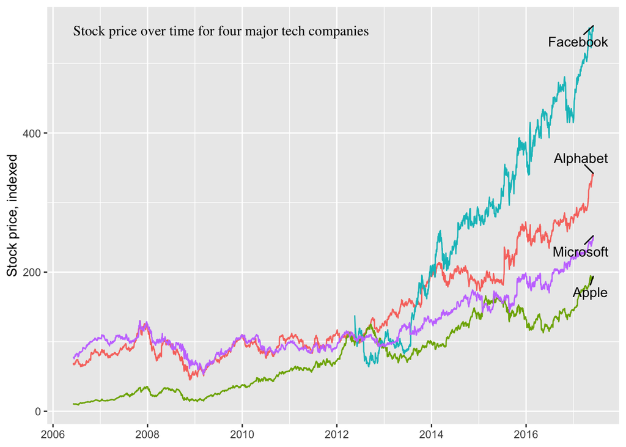

### Exercise 3

Using `corruption.rda` dataset, recreate the following graphic as precisely as possible.

*Hints:*

- Transparency is 0.6
- Only use 2015 data
- Color used is `grey60`
- `"y ~ log(x)"` (method `"lm"`)
- Package `ggrepel`
- `box.padding` is 0.6
- Minimum segment length is 0
- seed is 9876

```r
# Dataset for labels
country_highlight <- c(
  "United States", "Singapore", "Ghana", "Niger",
  "Chile", "Argentina", "Japan", "China", "Iraq"
)
```

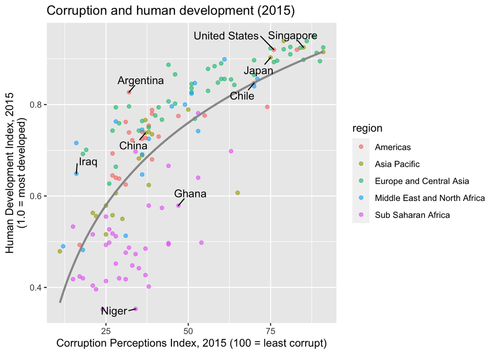

### Exercise 4

Using `cdc` dataset, recreate the described graphic as precisely as possible.

Using Bilbo Baggins’ responses below to the CDC BRSFF questions, add Bilbo’s data point as a transparent (0.5) solid red circle of size 4 to a scatterplot of `weight` by `height` with transparent (0.1) solid blue circles of size 2 as the plotting characters. In addition, label the point with his name in red. Left justify and rotate the label so it reads vertically from bottom to top — shift it up by 10 pounds too. Plot should use appropriately formatted axis labels. Remember that the default shape is a solid circle.

- `genhlth` - How would you rate your general health? **fair**
- `exerany` - Have you exercised in the past month? **1=yes**
- `hlthplan` - Do you have some form of health coverage? **0=no**
- `smoke100` - Have you smoked at least 100 cigarettes in your life time? **1=yes**
- `height` - height in inches: **46**
- `weight` - weight in pounds: **120**
- `wtdesire` - weight desired in pounds: **120**
- `age` - in years: **45**
- `gender` - m for males and f for females: **m**

*Hint:* Create a new dataset (maybe call it `bilbo` or `bilbo_baggins`) using either `data.frame()` (base R - example in book) or `tibble()` (tidyverse - see help documentation for the function). Make sure to use variable names that exactly match `cdc`’s variable names

```r
# Build dataset for Bilbo Baggins
# tidyverse way to build data: Base R is data.frame()
bilbo <- tibble(
  genhlth  = "fair",
  exerany  = 1,
  hlthplan = 0,
  smoke100 = 1,
  height   = 46,
  weight   = 120,
  wtdesire = 120,
  age      = 45,
  gender   = "m"
)
```